> **Tip**: Welcome to the Investigate a Dataset project! You will find tips in quoted sections like this to help organize your approach to your investigation. Before submitting your project, it will be a good idea to go back through your report and remove these sections to make the presentation of your work as tidy as possible. First things first, you might want to double-click this Markdown cell and change the title so that it reflects your dataset and investigation.

# Project: Investigate the tmdb movies dataset.

- Introduction
- Data Wrangling
- Exploratory Data Analysis
- Conclusions

### ##Introduction:

[output not shown]

## Data Wrangling

```python
#Importing the necessary libraries
import pandas as pd
import matplotlib.pyplot as plt
import seaborn as sns
import numpy as np
from babel.numbers import format_currency
%matplotlib inline
```

```python
#Reading from the csv dataset
movies = pd.read_csv('tmdb-movies.csv')
movies.head(15)
```

|  | id | imdb_id | popularity | budget | revenue | original_title | cast | homepage | director | tagline | ... | overview | runtime | genres | production_companies | release_date | vote_count | vote_average | release_year | budget_adj | revenue_adj |
| --- | --- | --- | --- | --- | --- | --- | --- | --- | --- | --- | --- | --- | --- | --- | --- | --- | --- | --- | --- | --- | --- |
| 0 | 135397 | tt0369610 | 32.985763 | 150000000 | 1513528810 | Jurassic World | Chris Pratt\|Bryce Dallas Howard\|Irrfan Khan\|Vi... | http://www.jurassicworld.com/ | Colin Trevorrow | The park is open. | ... | Twenty-two years after the events of Jurassic ... | 124 | Action\|Adventure\|Science Fiction\|Thriller | Universal Studios\|Amblin Entertainment\|Legenda... | 6/9/2015 | 5562 | 6.5 | 2015 | 1.379999e+08 | 1.392446e+09 |
| 1 | 76341 | tt1392190 | 28.419936 | 150000000 | 378436354 | Mad Max: Fury Road | Tom Hardy\|Charlize Theron\|Hugh Keays-Byrne\|Nic... | http://www.madmaxmovie.com/ | George Miller | What a Lovely Day. | ... | An apocalyptic story set in the furthest reach... | 120 | Action\|Adventure\|Science Fiction\|Thriller | Village Roadshow Pictures\|Kennedy Miller Produ... | 5/13/2015 | 6185 | 7.1 | 2015 | 1.379999e+08 | 3.481613e+08 |
| 2 | 262500 | tt2908446 | 13.112507 | 110000000 | 295238201 | Insurgent | Shailene Woodley\|Theo James\|Kate Winslet\|Ansel... | http://www.thedivergentseries.movie/#insurgent | Robert Schwentke | One Choice Can Destroy You | ... | Beatrice Prior must confront her inner demons ... | 119 | Adventure\|Science Fiction\|Thriller | Summit Entertainment\|Mandeville Films\|Red Wago... | 3/18/2015 | 2480 | 6.3 | 2015 | 1.012000e+08 | 2.716190e+08 |
| 3 | 140607 | tt2488496 | 11.173104 | 200000000 | 2068178225 | Star Wars: The Force Awakens | Harrison Ford\|Mark Hamill\|Carrie Fisher\|Adam D... | http://www.starwars.com/films/star-wars-episod... | J.J. Abrams | Every generation has a story. | ... | Thirty years after defeating the Galactic Empi... | 136 | Action\|Adventure\|Science Fiction\|Fantasy | Lucasfilm\|Truenorth Productions\|Bad Robot | 12/15/2015 | 5292 | 7.5 | 2015 | 1.839999e+08 | 1.902723e+09 |
| 4 | 168259 | tt2820852 | 9.335014 | 190000000 | 1506249360 | Furious 7 | Vin Diesel\|Paul Walker\|Jason Statham\|Michelle ... | http://www.furious7.com/ | James Wan | Vengeance Hits Home | ... | Deckard Shaw seeks revenge against Dominic Tor... | 137 | Action\|Crime\|Thriller | Universal Pictures\|Original Film\|Media Rights ... | 4/1/2015 | 2947 | 7.3 | 2015 | 1.747999e+08 | 1.385749e+09 |
| 5 | 281957 | tt1663202 | 9.110700 | 135000000 | 532950503 | The Revenant | Leonardo DiCaprio\|Tom Hardy\|Will Poulter\|Domhn... | http://www.foxmovies.com/movies/the-revenant | Alejandro González Iñárritu | (n. One who has returned, as if from the dead.) | ... | In the 1820s, a frontiersman, Hugh Glass, sets... | 156 | Western\|Drama\|Adventure\|Thriller | Regency Enterprises\|Appian Way\|CatchPlay\|Anony... | 12/25/2015 | 3929 | 7.2 | 2015 | 1.241999e+08 | 4.903142e+08 |
| 6 | 87101 | tt1340138 | 8.654359 | 155000000 | 440603537 | Terminator Genisys | Arnold Schwarzenegger\|Jason Clarke\|Emilia Clar... | http://www.terminatormovie.com/ | Alan Taylor | Reset the future | ... | The year is 2029. John Connor, leader of the r... | 125 | Science Fiction\|Action\|Thriller\|Adventure | Paramount Pictures\|Skydance Productions | 6/23/2015 | 2598 | 5.8 | 2015 | 1.425999e+08 | 4.053551e+08 |
| 7 | 286217 | tt3659388 | 7.667400 | 108000000 | 595380321 | The Martian | Matt Damon\|Jessica Chastain\|Kristen Wiig\|Jeff ... | http://www.foxmovies.com/movies/the-martian | Ridley Scott | Bring Him Home | ... | During a manned mission to Mars, Astronaut Mar... | 141 | Drama\|Adventure\|Science Fiction | Twentieth Century Fox Film Corporation\|Scott F... | 9/30/2015 | 4572 | 7.6 | 2015 | 9.935996e+07 | 5.477497e+08 |
| 8 | 211672 | tt2293640 | 7.404165 | 74000000 | 1156730962 | Minions | Sandra Bullock\|Jon Hamm\|Michael Keaton\|Allison... | http://www.minionsmovie.com/ | Kyle Balda\|Pierre Coffin | Before Gru, they had a history of bad bosses | ... | Minions Stuart, Kevin and Bob are recruited by... | 91 | Family\|Animation\|Adventure\|Comedy | Universal Pictures\|Illumination Entertainment | 6/17/2015 | 2893 | 6.5 | 2015 | 6.807997e+07 | 1.064192e+09 |
| 9 | 150540 | tt2096673 | 6.326804 | 175000000 | 853708609 | Inside Out | Amy Poehler\|Phyllis Smith\|Richard Kind\|Bill Ha... | http://movies.disney.com/inside-out | Pete Docter | Meet the little voices inside your head. | ... | Growing up can be a bumpy road, and it's no ex... | 94 | Comedy\|Animation\|Family | Walt Disney Pictures\|Pixar Animation Studios\|W... | 6/9/2015 | 3935 | 8.0 | 2015 | 1.609999e+08 | 7.854116e+08 |
| 10 | 206647 | tt2379713 | 6.200282 | 245000000 | 880674609 | Spectre | Daniel Craig\|Christoph Waltz\|Léa Seydoux\|Ralp... | http://www.sonypictures.com/movies/spectre/ | Sam Mendes | A Plan No One Escapes | ... | A cryptic message from Bond’s past sends him... | 148 | Action\|Adventure\|Crime | Columbia Pictures\|Danjaq\|B24 | 10/26/2015 | 3254 | 6.2 | 2015 | 2.253999e+08 | 8.102203e+08 |
| 11 | 76757 | tt1617661 | 6.189369 | 176000003 | 183987723 | Jupiter Ascending | Mila Kunis\|Channing Tatum\|Sean Bean\|Eddie Redm... | http://www.jupiterascending.com | Lana Wachowski\|Lilly Wachowski | Expand your universe. | ... | In a universe where human genetic material is ... | 124 | Science Fiction\|Fantasy\|Action\|Adventure | Village Roadshow Pictures\|Dune Entertainment\|A... | 2/4/2015 | 1937 | 5.2 | 2015 | 1.619199e+08 | 1.692686e+08 |
| 12 | 264660 | tt0470752 | 6.118847 | 15000000 | 36869414 | Ex Machina | Domhnall Gleeson\|Alicia Vikander\|Oscar Isaac\|S... | http://exmachina-movie.com/ | Alex Garland | There is nothing more human than the will to s... | ... | Caleb, a 26 year old coder at the world's larg... | 108 | Drama\|Science Fiction | DNA Films\|Universal Pictures International (UP... | 1/21/2015 | 2854 | 7.6 | 2015 | 1.379999e+07 | 3.391985e+07 |
| 13 | 257344 | tt2120120 | 5.984995 | 88000000 | 243637091 | Pixels | Adam Sandler\|Michelle Monaghan\|Peter Dinklage\|... | http://www.pixels-movie.com/ | Chris Columbus | Game On. | ... | Video game experts are recruited by the milita... | 105 | Action\|Comedy\|Science Fiction | Columbia Pictures\|Happy Madison Productions | 7/16/2015 | 1575 | 5.8 | 2015 | 8.095996e+07 | 2.241460e+08 |
| 14 | 99861 | tt2395427 | 5.944927 | 280000000 | 1405035767 | Avengers: Age of Ultron | Robert Downey Jr.\|Chris Hemsworth\|Mark Ruffalo... | http://marvel.com/movies/movie/193/avengers_ag... | Joss Whedon | A New Age Has Come. | ... | When Tony Stark tries to jumpstart a dormant p... | 141 | Action\|Adventure\|Science Fiction | Marvel Studios\|Prime Focus\|Revolution Sun Studios | 4/22/2015 | 4304 | 7.4 | 2015 | 2.575999e+08 | 1.292632e+09 |

15 rows × 21 columns

```python
movies.info() #Viewing the fields namase,their data types and sizes
```

```
<class 'pandas.core.frame.DataFrame'>
RangeIndex: 10866 entries, 0 to 10865
Data columns (total 21 columns):
id                      10866 non-null int64
imdb_id                 10856 non-null object
popularity              10866 non-null float64
budget                  10866 non-null int64
revenue                 10866 non-null int64
original_title          10866 non-null object
cast                    10790 non-null object
homepage                2936 non-null object
director                10822 non-null object
tagline                 8042 non-null object
keywords                9373 non-null object
overview                10862 non-null object
runtime                 10866 non-null int64
genres                  10843 non-null object
production_companies    9836 non-null object
release_date            10866 non-null object
vote_count              10866 non-null int64
vote_average            10866 non-null float64
release_year            10866 non-null int64
budget_adj              10866 non-null float64
revenue_adj             10866 non-null float64
dtypes: float64(4), int64(6), object(11)
memory usage: 1.3+ MB
```

```python
movies['release_year'].unique() #-> release dates show that the data consists of movies ranging from 1960 to 2015
```

```
array([2015, 2014, 1977, 2009, 2010, 1999, 2001, 2008, 2011, 2002, 1994,
       2012, 2003, 1997, 2013, 1985, 2005, 2006, 2004, 1972, 1980, 2007,
       1979, 1984, 1983, 1995, 1992, 1981, 1996, 2000, 1982, 1998, 1989,
       1991, 1988, 1987, 1968, 1974, 1975, 1962, 1964, 1971, 1990, 1961,
       1960, 1976, 1993, 1967, 1963, 1986, 1973, 1970, 1965, 1969, 1978,
       1966], dtype=int64)
```

```python
movies['release_year'].unique().max()#highest year in release year
```

```
2015
```

```python
movies['release_year'].unique().min()#lowest in release year
```

```
1960
```

```python
movies['id'].nunique() #-> This indicates that there is one duplicate row
```

```
10865
```

```python
#identifying the duplicate rows
movies[movies.duplicated(keep = False)]
```

|  | id | imdb_id | popularity | budget | revenue | original_title | cast | homepage | director | tagline | ... | overview | runtime | genres | production_companies | release_date | vote_count | vote_average | release_year | budget_adj | revenue_adj |
| --- | --- | --- | --- | --- | --- | --- | --- | --- | --- | --- | --- | --- | --- | --- | --- | --- | --- | --- | --- | --- | --- |
| 2089 | 42194 | tt0411951 | 0.59643 | 30000000 | 967000 | TEKKEN | Jon Foo\|Kelly Overton\|Cary-Hiroyuki Tagawa\|Ian... | NaN | Dwight H. Little | Survival is no game | ... | In the year of 2039, after World Wars destroy ... | 92 | Crime\|Drama\|Action\|Thriller\|Science Fiction | Namco\|Light Song Films | 3/20/2010 | 110 | 5.0 | 2010 | 30000000.0 | 967000.0 |
| 2090 | 42194 | tt0411951 | 0.59643 | 30000000 | 967000 | TEKKEN | Jon Foo\|Kelly Overton\|Cary-Hiroyuki Tagawa\|Ian... | NaN | Dwight H. Little | Survival is no game | ... | In the year of 2039, after World Wars destroy ... | 92 | Crime\|Drama\|Action\|Thriller\|Science Fiction | Namco\|Light Song Films | 3/20/2010 | 110 | 5.0 | 2010 | 30000000.0 | 967000.0 |

2 rows × 21 columns

```python
movies.loc[movies['budget'] == 0]  #-> from the below output we can see that there are rows with budget = 0 and/or revenue = 0. These are missing data.
```

|  | id | imdb_id | popularity | budget | revenue | original_title | cast | homepage | director | tagline | ... | overview | runtime | genres | production_companies | release_date | vote_count | vote_average | release_year | budget_adj | revenue_adj |
| --- | --- | --- | --- | --- | --- | --- | --- | --- | --- | --- | --- | --- | --- | --- | --- | --- | --- | --- | --- | --- | --- |
| 30 | 280996 | tt3168230 | 3.927333 | 0 | 29355203 | Mr. Holmes | Ian McKellen\|Milo Parker\|Laura Linney\|Hattie M... | http://www.mrholmesfilm.com/ | Bill Condon | The man behind the myth | ... | The story is set in 1947, following a long-ret... | 103 | Mystery\|Drama | BBC Films\|See-Saw Films\|FilmNation Entertainme... | 6/19/2015 | 425 | 6.4 | 2015 | 0.0 | 2.700677e+07 |
| 36 | 339527 | tt1291570 | 3.358321 | 0 | 22354572 | Solace | Abbie Cornish\|Jeffrey Dean Morgan\|Colin Farrel... | NaN | Afonso Poyart | A serial killer who can see your future, a psy... | ... | A psychic doctor, John Clancy, works with an F... | 101 | Crime\|Drama\|Mystery | Eden Rock Media\|FilmNation Entertainment\|Flynn... | 9/3/2015 | 474 | 6.2 | 2015 | 0.0 | 2.056620e+07 |
| 72 | 284289 | tt2911668 | 2.272044 | 0 | 45895 | Beyond the Reach | Michael Douglas\|Jeremy Irvine\|Hanna Mangan Law... | NaN | Jean-Baptiste Léonetti | NaN | ... | A high-rolling corporate shark and his impover... | 95 | Thriller | Furthur Films | 4/17/2015 | 81 | 5.5 | 2015 | 0.0 | 4.222338e+04 |
| 74 | 347096 | tt3478232 | 2.165433 | 0 | 0 | Mythica: The Darkspore | Melanie Stone\|Kevin Sorbo\|Adam Johnson\|Jake St... | http://www.mythicamovie.com/#!blank/wufvh | Anne K. Black | NaN | ... | When Teela’s sister is murdered and a powerf... | 108 | Action\|Adventure\|Fantasy | Arrowstorm Entertainment | 6/24/2015 | 27 | 5.1 | 2015 | 0.0 | 0.000000e+00 |
| 75 | 308369 | tt2582496 | 2.141506 | 0 | 0 | Me and Earl and the Dying Girl | Thomas Mann\|RJ Cyler\|Olivia Cooke\|Connie Britt... | http://www.foxsearchlight.com/meandearlandthed... | Alfonso Gomez-Rejon | A Little Friendship Never Killed Anyone. | ... | Greg is coasting through senior year of high s... | 105 | Comedy\|Drama | Indian Paintbrush | 6/12/2015 | 569 | 7.7 | 2015 | 0.0 | 0.000000e+00 |
| 88 | 301875 | tt3289728 | 1.959765 | 0 | 2000000 | Equals | Kristen Stewart\|Nicholas Hoult\|Guy Pearce\|Jack... | http://equals-the-movie.com/ | Drake Doremus | Find your equal. | ... | A futuristic love story set in a world where e... | 101 | Drama\|Romance\|Science Fiction | Scott Free Productions\|Infinite Frameworks Stu... | 9/4/2015 | 135 | 5.6 | 2015 | 0.0 | 1.839999e+06 |
| 92 | 370687 | tt3608646 | 1.876037 | 0 | 0 | Mythica: The Necromancer | Melanie Stone\|Adam Johnson\|Kevin Sorbo\|Nicola ... | http://www.mythicamovie.com/#!blank/y9ake | A. Todd Smith | NaN | ... | Mallister takes Thane prisoner and forces Mare... | 0 | Fantasy\|Action\|Adventure | Arrowstorm Entertainment\|Camera 40 Productions... | 12/19/2015 | 11 | 5.4 | 2015 | 0.0 | 0.000000e+00 |
| 95 | 258509 | tt2974918 | 1.841779 | 0 | 233755553 | Alvin and the Chipmunks: The Road Chip | Jason Lee\|Justin Long\|Bella Thorne\|Matthew Gra... | http://www.foxmovies.com/movies/alvin-and-the-... | Walt Becker | Fast & furry-ous | ... | Through a series of misunderstandings, Alvin, ... | 92 | Adventure\|Animation\|Comedy\|Family | Regency Enterprises\|Fox 2000 Pictures\|Sunswept... | 12/17/2015 | 278 | 5.7 | 2015 | 0.0 | 2.150550e+08 |
| 100 | 326359 | tt4007502 | 1.724712 | 0 | 0 | Frozen Fever | Kristen Bell\|Idina Menzel\|Jonathan Groff\|Josh ... | NaN | Chris Buck\|Jennifer Lee | NaN | ... | On Anna's birthday, Elsa and Kristoff are dete... | 8 | Adventure\|Animation\|Family | Walt Disney Pictures\|Walt Disney Animation Stu... | 3/9/2015 | 475 | 7.0 | 2015 | 0.0 | 0.000000e+00 |
| 101 | 254302 | tt0462335 | 1.661789 | 0 | 0 | High-Rise | Tom Hiddleston\|Sienna Miller\|Jeremy Irons\|Luke... | NaN | Ben Wheatley | Leave the real world behind | ... | Dr. Robert Laing is the newest resident of a l... | 119 | Action\|Drama\|Science Fiction | Ingenious Media\|HanWay Films\|Scope Pictures\|Re... | 9/26/2015 | 161 | 5.4 | 2015 | 0.0 | 0.000000e+00 |
| 103 | 292040 | tt3321300 | 1.646664 | 0 | 0 | Spooks: The Greater Good | Peter Firth\|Kit Harington\|Jennifer Ehle\|Lara P... | http://www.shinepictures.co.uk/films/9/spooks-... | Bharat Nalluri | NaN | ... | During a handover to the head of counter-terro... | 104 | Thriller\|Action | BBC Films\|Isle of Man Film\|Shine Pictures\|Kudo... | 4/11/2015 | 114 | 5.6 | 2015 | 0.0 | 0.000000e+00 |
| 116 | 297291 | tt3086386 | 1.380320 | 0 | 0 | The Scorpion King: The Lost Throne | Victor Webster\|Ellen Hollman\|Barry Bostwick\|Wi... | NaN | Mike Elliott | Action Adventure | ... | When he is betrayed by a trusted friend, Matha... | 105 | Action\|Fantasy\|Adventure | Universal Pictures | 1/9/2015 | 22 | 4.5 | 2015 | 0.0 | 0.000000e+00 |
| 119 | 86828 | tt1727770 | 1.360827 | 0 | 5189646 | Absolutely Anything | Simon Pegg\|Kate Beckinsale\|Rob Riggle\|Sanjeev ... | NaN | Terry Jones | Great power. Total irresponsibility. | ... | Eccentric aliens give a man the power to do an... | 85 | Comedy\|Science Fiction | Premiere Picture\|Bill and Ben Productions\|GFM ... | 6/26/2015 | 199 | 5.8 | 2015 | 0.0 | 4.774472e+06 |
| 122 | 277355 | tt1945084 | 1.342839 | 0 | 0 | Everly | Salma Hayek\|Hiroyuki Watanabe\|Jennifer Blanc\|T... | NaN | Joe Lynch | Enter if you dare. | ... | After she betrays a powerful mob boss, a woman... | 90 | Thriller\|Action | Crime Scene Pictures\|Radius-TWC\|Anonymous Cont... | 1/23/2015 | 169 | 5.1 | 2015 | 0.0 | 0.000000e+00 |
| 125 | 223485 | tt3205376 | 1.329702 | 0 | 229094 | Slow West | Michael Fassbender\|Kodi Smit-McPhee\|Ben Mendel... | NaN | John Maclean | Wanted Dead or Dead | ... | In the Old West, a 17-year-old Scottish boy te... | 84 | Romance\|Thriller\|Western | The New Zealand Film Commission\|Film4\|See Saw ... | 4/16/2015 | 229 | 6.6 | 2015 | 0.0 | 2.107664e+05 |
| 128 | 309245 | tt2872462 | 1.293140 | 0 | 2500431 | Mistress America | Greta Gerwig\|Lola Kirke\|Charlie Gillette\|Dean ... | NaN | Noah Baumbach | From Strangers to Sisters. | ... | Tracy, a lonely college freshman in New York, ... | 84 | Comedy | RT Features | 8/14/2015 | 132 | 6.4 | 2015 | 0.0 | 2.300396e+06 |
| 130 | 245706 | tt2273657 | 1.284541 | 0 | 4719695 | True Story | Jonah Hill\|James Franco\|Felicity Jones\|Maria D... | NaN | Rupert Goold | Some mysteries are beyond belief. | ... | A drama centered around the relationship betwe... | 100 | Crime\|Drama\|Mystery | Plan B Entertainment\|Regency Enterprises\|New R... | 4/17/2015 | 354 | 6.0 | 2015 | 0.0 | 4.342117e+06 |
| 132 | 263109 | tt2872750 | 1.253580 | 0 | 59700000 | Shaun the Sheep Movie | Justin Fletcher\|Omid Djalili\|Richard Webber\|Ka... | http://www.shaunthesheep.com/ | Mark Burton\|Richard Starzack | Moving on to Pastures New. | ... | When Shaun decides to take the day off and hav... | 85 | Family\|Animation\|Comedy\|Adventure | Aardman Animations\|Studio Canal\|Anton Capital ... | 2/5/2015 | 340 | 6.9 | 2015 | 0.0 | 5.492398e+07 |
| 134 | 321751 | tt3577624 | 1.245224 | 0 | 1702433 | A Perfect Day | Olga Kurylenko\|Benicio del Toro\|Tim Robbins\|MÃ... | NaN | Fernando León de Aranoa | NaN | ... | Film about a group of aid workers trying to re... | 106 | Comedy\|Drama | Reposado Producciones\|Televisión Española (T... | 8/28/2015 | 102 | 6.3 | 2015 | 0.0 | 1.566238e+06 |
| 139 | 193687 | tt1598642 | 1.161812 | 0 | 118483 | Z for Zachariah | Margot Robbie\|Chiwetel Ejiofor\|Chris Pine | http://www.facebook.com/ZforZachariah | Craig Zobel | After the end of the world she thought she was... | ... | In the wake of a nuclear war, a young woman su... | 97 | Drama\|Science Fiction\|Thriller | Palomar Pictures\|Lucky Hat Entertainment\|Silve... | 8/13/2015 | 181 | 5.5 | 2015 | 0.0 | 1.090043e+05 |
| 140 | 300803 | tt3829170 | 1.144808 | 0 | 0 | Dragonheart 3: The Sorcerer's Curse | Julian Morris\|Tamzin Merchant\|Jassa Ahluwalia\|... | NaN | Colin Teague | NaN | ... | When aspiring knight Gareth goes in search of ... | 97 | Action\|Adventure\|Fantasy | Raffaella Productions | 2/24/2015 | 59 | 4.5 | 2015 | 0.0 | 0.000000e+00 |
| 143 | 378373 | tt3532278 | 1.128081 | 0 | 0 | Brothers of the Wind | Manuel Camacho\|Jean Reno\|Tobias Moretti\|Eva Kuen | http://www.terramater.at/cinema/brothers-of-th... | Gerado Olivares\|Otmar Penker | Sometimes a friendship sets you free | ... | The way of the eagle is to raise two chicks. T... | 98 | Adventure\|Drama\|Family | Terra Mater Factual Studios | 12/24/2015 | 11 | 7.5 | 2015 | 0.0 | 0.000000e+00 |
| 146 | 241257 | tt3319920 | 1.065888 | 0 | 17671101 | Regression | Ethan Hawke\|Emma Watson\|Aaron Ashmore\|Devon Bo... | NaN | Alejandro Amenábar | Fear always finds its victim | ... | Minnesota, 1990. Detective Bruce Kenner (Ethan... | 106 | Horror\|Mystery\|Thriller | The Weinstein Company\|Himenóptero\|First Gener... | 10/1/2015 | 310 | 5.2 | 2015 | 0.0 | 1.625741e+07 |
| 147 | 245698 | tt1596345 | 1.063055 | 0 | 0 | Pawn Sacrifice | Tobey Maguire\|Lily Rabe\|Peter Sarsgaard\|Liev S... | NaN | Edward Zwick | On the board he fought the Cold War. In his mi... | ... | American chess champion Bobby Fischer prepares... | 114 | Drama | Material Pictures\|MICA Entertainment\|PalmStar ... | 9/16/2015 | 148 | 6.6 | 2015 | 0.0 | 0.000000e+00 |
| 148 | 353326 | tt0787524 | 1.046518 | 0 | 11472454 | The Man Who Knew Infinity | Jeremy Irons\|Dev Patel\|Toby Jones\|Stephen Fry\|... | http://www.ifcfilms.com/films/the-man-who-knew... | Matt Brown | What does it take to prove the impossible? | ... | Growing up poor in Madras, India, Srinivasa Ra... | 108 | Drama | Animus Films\|Edward R. Pressman Film\|Kreo Film... | 9/17/2015 | 104 | 7.1 | 2015 | 0.0 | 1.055465e+07 |
| 151 | 290637 | tt3733778 | 1.036825 | 0 | 0 | Pay the Ghost | Nicolas Cage\|Sarah Wayne Callies\|Veronica Ferr... | NaN | Uli Edel | Evil walks among us. | ... | One year after his young son disappeared durin... | 94 | Horror\|Thriller | Voltage Films\|Midnight Kitchen Productions | 9/16/2015 | 114 | 5.3 | 2015 | 0.0 | 0.000000e+00 |
| 152 | 244458 | tt1567437 | 1.027620 | 0 | 0 | The Voices | Ryan Reynolds\|Gemma Arterton\|Anna Kendrick\|Jac... | NaN | Marjane Satrapi | Hearing voices can be murder. | ... | A mentally unhinged factory worker must decide... | 101 | Horror\|Thriller\|Comedy\|Crime | Studio Babelsberg\|Mandalay Vision\|1984 Private... | 2/6/2015 | 371 | 6.0 | 2015 | 0.0 | 0.000000e+00 |
| 153 | 308504 | tt2493486 | 1.021441 | 0 | 3643591 | Last Knights | Clive Owen\|Morgan Freeman\|Aksel Hennie\|Shohreh... | NaN | Kazuaki Kiriya | NaN | ... | When an evil emperor executes their leader, hi... | 115 | Action\|Adventure | Czech Anglo Productions\|Luka Productions | 4/3/2015 | 237 | 6.3 | 2015 | 0.0 | 3.352102e+06 |
| 158 | 290762 | tt2245003 | 0.953647 | 0 | 0 | Miss You Already | Drew Barrymore\|Toni Collette\|Dominic Cooper\|Ja... | NaN | Catherine Hardwicke | When life falls apart, friends keep it together | ... | The friendship between two life-long girlfrien... | 112 | Comedy\|Drama\|Romance | S Films\|New Sparta Films | 9/12/2015 | 139 | 7.2 | 2015 | 0.0 | 0.000000e+00 |
| 161 | 324807 | tt2056771 | 0.938432 | 0 | 1936524 | A Bigger Splash | Tilda Swinton\|Matthias Schoenaerts\|Ralph Fienn... | NaN | Luca Guadagnino | NaN | ... | An American couple, Paul and Marianne, spend t... | 120 | Crime\|Drama\|Mystery\|Thriller | StudioCanal\|Ministero per i Beni e le AttivitÃ... | 11/26/2015 | 69 | 5.8 | 2015 | 0.0 | 1.781601e+06 |
| ... | ... | ... | ... | ... | ... | ... | ... | ... | ... | ... | ... | ... | ... | ... | ... | ... | ... | ... | ... | ... | ... |
| 10830 | 4772 | tt0060268 | 0.380321 | 0 | 0 | Cul-de-sac | Donald Pleasence\|Françoise Dorléac\|Lionel St... | NaN | Roman Polanski | NaN | ... | A wounded criminal and his dying partner take ... | 113 | Comedy\|Drama\|Foreign\|Thriller | Tekli British Productions | 2/1/1966 | 18 | 6.7 | 1966 | 0.0 | 0.000000e+00 |
| 10831 | 1888 | tt0060424 | 0.529721 | 0 | 0 | The Fortune Cookie | Jack Lemmon\|Walter Matthau\|Ron Rich\|Judi West\|... | NaN | Billy Wilder | Is he a spy? A security risk? Is he unfaithful... | ... | A cameraman is knocked over during a football ... | 125 | Romance\|Comedy | Phalanx-Jaelem | 10/19/1966 | 17 | 6.4 | 1966 | 0.0 | 0.000000e+00 |
| 10833 | 3001 | tt0060522 | 0.737730 | 0 | 0 | How to Steal a Million | Audrey Hepburn\|Peter O'Toole\|Eli Wallach\|Hugh ... | NaN | William Wyler | A movie about those who appreciate the finest ... | ... | A woman must steal a statue from a Paris museu... | 123 | Comedy\|Crime\|Romance | World Wide Productions | 7/13/1966 | 67 | 7.3 | 1966 | 0.0 | 0.000000e+00 |
| 10834 | 12639 | tt0060897 | 0.310688 | 0 | 0 | Return of the Seven | Yul Brynner\|Robert Fuller\|Julián Mateos\|Warre... | NaN | Burt Kennedy | Between the law and the lawless - SEVEN again.... | ... | Chico one of the remaining members of The Magn... | 95 | Action\|Western | C.B. Films S.A.\|The Mirisch Production Company | 10/19/1966 | 14 | 5.1 | 1966 | 0.0 | 0.000000e+00 |
| 10836 | 38720 | tt0061170 | 0.239435 | 0 | 0 | Walk Don't Run | Cary Grant\|Samantha Eggar\|Jim Hutton\|John Stan... | NaN | Charles Walters | Run, don't walk to see Walk, Don't Run. | ... | British industrialist Sir William Rutland - "B... | 114 | Comedy\|Romance | Columbia Pictures Corporation | 1/1/1966 | 11 | 5.8 | 1966 | 0.0 | 0.000000e+00 |
| 10837 | 19728 | tt0060177 | 0.291704 | 0 | 0 | The Blue Max | George Peppard\|James Mason\|Ursula Andress\|Jere... | NaN | John Guillermin | There was no quiet on the Western Front! | ... | A young pilot in the German air force of 1918,... | 156 | War\|Action\|Adventure\|Drama | Twentieth Century Fox Film Corporation | 6/21/1966 | 12 | 5.5 | 1966 | 0.0 | 0.000000e+00 |
| 10838 | 22383 | tt0060862 | 0.151845 | 0 | 0 | The Professionals | Burt Lancaster\|Lee Marvin\|Robert Ryan\|Woody St... | NaN | Richard Brooks | Rough, tough and ready. | ... | The Professionals is a 1966 American Western f... | 117 | Action\|Adventure\|Western | Columbia Pictures | 11/1/1966 | 21 | 6.0 | 1966 | 0.0 | 0.000000e+00 |
| 10839 | 13353 | tt0060550 | 0.276133 | 0 | 0 | It's the Great Pumpkin, Charlie Brown | Christopher Shea\|Sally Dryer\|Kathy Steinberg\|A... | NaN | Bill Melendez | Every year he rises from the pumpkin patch... | ... | This classic "Peanuts" tale focuses on the thu... | 25 | Family\|Animation | Warner Bros. Home Video | 10/27/1966 | 49 | 7.2 | 1966 | 0.0 | 0.000000e+00 |
| 10840 | 34388 | tt0060437 | 0.102530 | 0 | 0 | Funeral in Berlin | Michael Caine\|Paul Hubschmid\|Oskar Homolka\|Eva... | NaN | Guy Hamilton | NaN | ... | Colonel Stok, a Soviet intelligence officer re... | 102 | Thriller | Lowndes Productions Limited | 12/22/1966 | 13 | 5.7 | 1966 | 0.0 | 0.000000e+00 |
| 10842 | 36540 | tt0061199 | 0.253437 | 0 | 0 | Winnie the Pooh and the Honey Tree | Sterling Holloway\|Junius Matthews\|Sebastian Ca... | NaN | Wolfgang Reitherman | NaN | ... | Christopher Robin's bear attempts to raid a be... | 25 | Animation\|Family | NaN | 1/1/1966 | 12 | 7.9 | 1966 | 0.0 | 0.000000e+00 |
| 10843 | 29710 | tt0060588 | 0.252399 | 0 | 0 | Khartoum | Charlton Heston\|Laurence Olivier\|Richard Johns... | NaN | Basil Dearden\|Eliot Elisofon | Where the Nile divides, the great Cinerama adv... | ... | English General Charles George Gordon, a devou... | 134 | Adventure\|Drama\|War\|History\|Action | Julian Blaustein Productions Ltd. | 6/9/1966 | 12 | 5.8 | 1966 | 0.0 | 0.000000e+00 |
| 10844 | 23728 | tt0059557 | 0.236098 | 0 | 0 | Our Man Flint | James Coburn\|Lee J. Cobb\|Gila Golan\|Edward Mul... | NaN | Daniel Mann | The ORIGINAL man of mystery! | ... | When scientists use eco-terrorism to impose th... | 108 | Adventure\|Comedy\|Fantasy\|Science Fiction | 20th Century Fox | 1/16/1966 | 13 | 5.6 | 1966 | 0.0 | 0.000000e+00 |
| 10845 | 5065 | tt0059014 | 0.230873 | 0 | 0 | Carry On Cowboy | Sid James\|Jim Dale\|Angela Douglas\|Kenneth Will... | NaN | Gerald Thomas | How the west was lost! | ... | Stodge City is in the grip of the Rumpo Kid an... | 93 | Comedy\|Western | Peter Rogers Productions | 3/1/1966 | 15 | 5.9 | 1966 | 0.0 | 0.000000e+00 |
| 10846 | 17102 | tt0059127 | 0.212716 | 0 | 0 | Dracula: Prince of Darkness | Christopher Lee\|Barbara Shelley\|Andrew Keir\|Fr... | NaN | Terence Fisher | DEAD for Ten Years DRACULA, Prince of Darkness... | ... | Whilst vacationing in the Carpathian Mountain,... | 90 | Horror | Seven Arts Productions\|Hammer Film Productions | 1/9/1966 | 16 | 5.7 | 1966 | 0.0 | 0.000000e+00 |
| 10847 | 28763 | tt0060548 | 0.034555 | 0 | 0 | Island of Terror | Peter Cushing\|Edward Judd\|Carole Gray\|Eddie By... | NaN | Terence Fisher | How could they stop the devouring death...that... | ... | A small island community is overrun with creep... | 89 | Science Fiction\|Horror | Planet Film Productions\|Protelco | 6/20/1966 | 13 | 5.3 | 1966 | 0.0 | 0.000000e+00 |
| 10849 | 28270 | tt0060445 | 0.206537 | 0 | 0 | Gambit | Michael Caine\|Shirley MacLaine\|Herbert Lom\|Joh... | NaN | Ronald Neame | Shirley MacLaine raises Michael Caine! | ... | Harry Dean (Michael Caine) has a perfect plan ... | 109 | Action\|Comedy\|Crime | Universal Pictures | 12/16/1966 | 14 | 6.1 | 1966 | 0.0 | 0.000000e+00 |
| 10850 | 26268 | tt0060490 | 0.202473 | 0 | 0 | Harper | Paul Newman\|Lauren Bacall\|Julie Harris\|Arthur ... | NaN | Jack Smight | Harper takes a case - and the payoff is murder. | ... | Harper is a cynical private eye in the best tr... | 121 | Action\|Drama\|Thriller\|Crime\|Mystery | Warner Bros. | 2/23/1966 | 14 | 6.0 | 1966 | 0.0 | 0.000000e+00 |
| 10851 | 15347 | tt0060182 | 0.342791 | 0 | 0 | Born Free | Virginia McKenna\|Bill Travers\|Geoffrey Keen\|Pe... | NaN | James Hill | From The Pages Of The Beloved Best Seller... A... | ... | Born Free (1966) is an Open Road Films Ltd./Co... | 95 | Adventure\|Drama\|Action\|Family\|Foreign | High Road | 6/22/1966 | 15 | 6.6 | 1966 | 0.0 | 0.000000e+00 |
| 10852 | 37301 | tt0060165 | 0.227220 | 0 | 0 | A Big Hand for the Little Lady | Henry Fonda\|Joanne Woodward\|Jason Robards\|Paul... | NaN | Fielder Cook | All the action you can take...all the adventur... | ... | A naive traveler in Laredo gets involved in a ... | 95 | Western | Eden Productions Inc. | 5/31/1966 | 11 | 6.0 | 1966 | 0.0 | 0.000000e+00 |
| 10853 | 15598 | tt0060086 | 0.163592 | 0 | 0 | Alfie | Michael Caine\|Shelley Winters\|Millicent Martin... | NaN | Lewis Gilbert | Is any man an Alfie? Ask any girl! | ... | The film tells the story of a young man who le... | 114 | Comedy\|Drama\|Romance | NaN | 3/29/1966 | 26 | 6.2 | 1966 | 0.0 | 0.000000e+00 |
| 10854 | 31602 | tt0060232 | 0.146402 | 0 | 0 | The Chase | Marlon Brando\|Jane Fonda\|Robert Redford\|E.G. M... | NaN | Arthur Penn | The chase is on! | ... | Most everyone in town thinks that Sheriff Cald... | 135 | Thriller\|Drama\|Crime | Horizon Pictures\|Columbia Pictures Corporation | 2/17/1966 | 17 | 6.0 | 1966 | 0.0 | 0.000000e+00 |
| 10856 | 20277 | tt0061135 | 0.140934 | 0 | 0 | The Ugly Dachshund | Dean Jones\|Suzanne Pleshette\|Charles Ruggles\|K... | NaN | Norman Tokar | A HAPPY HONEYMOON GOES TO THE DOGS!...When a G... | ... | The Garrisons (Dean Jones and Suzanne Pleshett... | 93 | Comedy\|Drama\|Family | Walt Disney Pictures | 2/16/1966 | 14 | 5.7 | 1966 | 0.0 | 0.000000e+00 |
| 10857 | 5921 | tt0060748 | 0.131378 | 0 | 0 | Nevada Smith | Steve McQueen\|Karl Malden\|Brian Keith\|Arthur K... | NaN | Henry Hathaway | Some called him savage- and some called him sa... | ... | Nevada Smith is the young son of an Indian mot... | 128 | Action\|Western | Paramount Pictures\|Solar Productions\|Embassy P... | 6/10/1966 | 10 | 5.9 | 1966 | 0.0 | 0.000000e+00 |
| 10858 | 31918 | tt0060921 | 0.317824 | 0 | 0 | The Russians Are Coming, The Russians Are Coming | Carl Reiner\|Eva Marie Saint\|Alan Arkin\|Brian K... | NaN | Norman Jewison | IT'S A PLOT! ...to make the world die laughing!! | ... | Without hostile intent, a Soviet sub runs agro... | 126 | Comedy\|War | The Mirisch Corporation | 5/25/1966 | 11 | 5.5 | 1966 | 0.0 | 0.000000e+00 |
| 10859 | 20620 | tt0060955 | 0.089072 | 0 | 0 | Seconds | Rock Hudson\|Salome Jens\|John Randolph\|Will Gee... | NaN | John Frankenheimer | NaN | ... | A secret organisation offers wealthy people a ... | 100 | Mystery\|Science Fiction\|Thriller\|Drama | Gibraltar Productions\|Joel Productions\|John Fr... | 10/5/1966 | 22 | 6.6 | 1966 | 0.0 | 0.000000e+00 |
| 10860 | 5060 | tt0060214 | 0.087034 | 0 | 0 | Carry On Screaming! | Kenneth Williams\|Jim Dale\|Harry H. Corbett\|Joa... | NaN | Gerald Thomas | Carry On Screaming with the Hilarious CARRY ON... | ... | The sinister Dr Watt has an evil scheme going.... | 87 | Comedy | Peter Rogers Productions\|Anglo-Amalgamated Fil... | 5/20/1966 | 13 | 7.0 | 1966 | 0.0 | 0.000000e+00 |
| 10861 | 21 | tt0060371 | 0.080598 | 0 | 0 | The Endless Summer | Michael Hynson\|Robert August\|Lord 'Tally Ho' B... | NaN | Bruce Brown | NaN | ... | The Endless Summer, by Bruce Brown, is one of ... | 95 | Documentary | Bruce Brown Films | 6/15/1966 | 11 | 7.4 | 1966 | 0.0 | 0.000000e+00 |
| 10862 | 20379 | tt0060472 | 0.065543 | 0 | 0 | Grand Prix | James Garner\|Eva Marie Saint\|Yves Montand\|Tosh... | NaN | John Frankenheimer | Cinerama sweeps YOU into a drama of speed and ... | ... | Grand Prix driver Pete Aron is fired by his te... | 176 | Action\|Adventure\|Drama | Cherokee Productions\|Joel Productions\|Douglas ... | 12/21/1966 | 20 | 5.7 | 1966 | 0.0 | 0.000000e+00 |
| 10863 | 39768 | tt0060161 | 0.065141 | 0 | 0 | Beregis Avtomobilya | Innokentiy Smoktunovskiy\|Oleg Efremov\|Georgi Z... | NaN | Eldar Ryazanov | NaN | ... | An insurance agent who moonlights as a carthie... | 94 | Mystery\|Comedy | Mosfilm | 1/1/1966 | 11 | 6.5 | 1966 | 0.0 | 0.000000e+00 |
| 10864 | 21449 | tt0061177 | 0.064317 | 0 | 0 | What's Up, Tiger Lily? | Tatsuya Mihashi\|Akiko Wakabayashi\|Mie Hama\|Joh... | NaN | Woody Allen | WOODY ALLEN STRIKES BACK! | ... | In comic Woody Allen's film debut, he took the... | 80 | Action\|Comedy | Benedict Pictures Corp. | 11/2/1966 | 22 | 5.4 | 1966 | 0.0 | 0.000000e+00 |

5696 rows × 21 columns

# Observations from the Dataset:

1. The fields 'budget','revenue','budget_adj' and 'revenue_adj' are currencies. We can assume that they are in dollars since thats not specified.
2. Number of votes per movie is different for each movie.i.e., the vote-count has different values. So we cannot use vote-count or vote_average to gauge the success/likeness of a movie.
3. The release year ranges from 1960 to 2015.
4. The dataset contains rows that have budgets and/or revenue as 0. These are missing data. Needs cleaning.
5. Any duplicate rows must also be cleaned(rows 2089 and 2090 are duplicates.
6. The unnecessory columns such as ` 'id', 'imdb_id', 'popularity', 'budget_adj', 'revenue_adj', 'homepage', 'keywords', 'overview', 'production_companies', 'vote_count' and 'vote_average' can be removed.
7. And date columns must be converted into date format.

### Data Cleaning

1. Removing the unnecessary columns  
   First the columns that dont add much value to the analysis can be removed.

```python
#get a list of columns to to be removed
list_of_col_to_del = [ 'id', 'imdb_id', 'popularity', 'budget_adj', 'revenue_adj', 'homepage', 'keywords', 'overview', 'production_companies', 'vote_count', 'vote_average']


#removing the unnecessary columns
movies_cleaned = movies.drop(list_of_col_to_del, 1)
movies_cleaned.rename(columns = {'budget' : 'budget_in_USD', 'revenue' : 'revenue_in_USD'}, inplace = True)
#displaying the new dataset
movies_cleaned.head(5)
```

|  | budget_in_USD | revenue_in_USD | original_title | cast | director | tagline | runtime | genres | release_date | release_year |
| --- | --- | --- | --- | --- | --- | --- | --- | --- | --- | --- |
| 0 | 150000000 | 1513528810 | Jurassic World | Chris Pratt\|Bryce Dallas Howard\|Irrfan Khan\|Vi... | Colin Trevorrow | The park is open. | 124 | Action\|Adventure\|Science Fiction\|Thriller | 6/9/2015 | 2015 |
| 1 | 150000000 | 378436354 | Mad Max: Fury Road | Tom Hardy\|Charlize Theron\|Hugh Keays-Byrne\|Nic... | George Miller | What a Lovely Day. | 120 | Action\|Adventure\|Science Fiction\|Thriller | 5/13/2015 | 2015 |
| 2 | 110000000 | 295238201 | Insurgent | Shailene Woodley\|Theo James\|Kate Winslet\|Ansel... | Robert Schwentke | One Choice Can Destroy You | 119 | Adventure\|Science Fiction\|Thriller | 3/18/2015 | 2015 |
| 3 | 200000000 | 2068178225 | Star Wars: The Force Awakens | Harrison Ford\|Mark Hamill\|Carrie Fisher\|Adam D... | J.J. Abrams | Every generation has a story. | 136 | Action\|Adventure\|Science Fiction\|Fantasy | 12/15/2015 | 2015 |
| 4 | 190000000 | 1506249360 | Furious 7 | Vin Diesel\|Paul Walker\|Jason Statham\|Michelle ... | James Wan | Vengeance Hits Home | 137 | Action\|Crime\|Thriller | 4/1/2015 | 2015 |

```python
#Get the number of rows and columns in the dataframe
print("Initial size of the dateframe:",movies.shape)
print("Size of the dataframe after removing unwanted columns: ",movies_cleaned.shape)
rows,cols = movies.shape
print("The new dataframe has {} rows/data entries and {} columns/features". format(rows-1,cols))
```

```
Initial size of the dateframe: (10866, 21)
Size of the dataframe after removing unwanted columns:  (10866, 10)
The new dataframe has 10865 rows/data entries and 21 columns/features
```

```python
#Viewing the duplicate rows
movies_cleaned[movies_cleaned.duplicated(keep = False)]
```

|  | budget_in_USD | revenue_in_USD | original_title | cast | director | tagline | runtime | genres | release_date | release_year |
| --- | --- | --- | --- | --- | --- | --- | --- | --- | --- | --- |
| 2089 | 30000000 | 967000 | TEKKEN | Jon Foo\|Kelly Overton\|Cary-Hiroyuki Tagawa\|Ian... | Dwight H. Little | Survival is no game | 92 | Crime\|Drama\|Action\|Thriller\|Science Fiction | 3/20/2010 | 2010 |
| 2090 | 30000000 | 967000 | TEKKEN | Jon Foo\|Kelly Overton\|Cary-Hiroyuki Tagawa\|Ian... | Dwight H. Little | Survival is no game | 92 | Crime\|Drama\|Action\|Thriller\|Science Fiction | 3/20/2010 | 2010 |

```python
#droping the duplicate rows
movies_cleaned.drop_duplicates(keep = 'last', inplace = True)
```

```python
movies_cleaned[movies_cleaned.duplicated(keep = False)] #checking if there are more duplicates
```

|  | budget_in_USD | revenue_in_USD | original_title | cast | director | tagline | runtime | genres | release_date | release_year |
| --- | --- | --- | --- | --- | --- | --- | --- | --- | --- | --- |

```python
def get_count(dataset,col,symbol,threshold):
    '''
    This function gets the number of rows that are having values in comparision to the threshold
    Symbol has the following:
    eq - equals
    ne - not equals'''
    if symbol == 'eq':
        return len(dataset[dataset[col]==threshold])
    elif symbol == 'ne':
        return len(dataset[dataset[col] != threshold])
```

```python
#There were zeros in the monetory fields which needs to be treated.
#We need to be concerned about the zeros in the budget and the revenue columns which is not goos.
#This can influence the results.
print("Total rows having budget as 0: ",get_count(movies_cleaned,'budget_in_USD','eq',0))
print("Total rows having revenue as 0: ",get_count(movies_cleaned,'revenue_in_USD','eq',0))
print("Total rows having runtime as 0: ",get_count(movies_cleaned,'runtime','eq',0))
```

```
Total rows having budget as 0:  5696
Total rows having revenue as 0:  6016
Total rows having runtime as 0:  31
```

```python
movies_cleaned.shape
```

```
(10865, 10)
```

Since there is a great percentage of rows having zeros, it is better to drop those instead of trying to replace the zeros with some number. To drop the zeros should be coverted to NANs and then can be dropped.

```python
#Replacing zeros with nans
movies_cleaned['budget_in_USD'] = movies_cleaned['budget_in_USD'].replace(0,np.nan)

movies_cleaned.shape
```

```
(10865, 10)
```

```python
#Replacing zeros with nans
movies_cleaned['revenue_in_USD'] = movies_cleaned['revenue_in_USD'].replace(0,np.nan)

movies_cleaned.shape
```

```
(10865, 10)
```

```python
#Replacing zeros with nans
movies_cleaned['runtime'] = movies_cleaned['runtime'].replace(0,np.nan)

movies_cleaned.shape
```

```
(10865, 10)
```

```python
movies_cleaned.dropna(subset = ['budget_in_USD','revenue_in_USD'], inplace = True)
movies_cleaned.shape
```

```
(3854, 10)
```

```python
#Checking the zeros
print("Total rows having budget as 0: ",get_count(movies_cleaned,'budget_in_USD','eq',0))
print("Total rows having revenue as 0: ",get_count(movies_cleaned,'revenue_in_USD','eq',0))
print("Total rows having runtime as 0: ",get_count(movies_cleaned,'runtime','eq',0))
```

```
Total rows having budget as 0:  0
Total rows having revenue as 0:  0
Total rows having runtime as 0:  0
```

```python
#The release_date should be changed from object type to date type
movies_cleaned.release_date.head(5)
```

```
0      6/9/2015
1     5/13/2015
2     3/18/2015
3    12/15/2015
4      4/1/2015
Name: release_date, dtype: object
```

```python
movies_cleaned.release_date = pd.to_datetime(movies_cleaned['release_date'])
movies_cleaned.release_date.head(5)
```

```
0   2015-06-09
1   2015-05-13
2   2015-03-18
3   2015-12-15
4   2015-04-01
Name: release_date, dtype: datetime64[ns]
```

```python
#Budget and revenue can be easily handled if they are in int type instead of float. Since the values are so large we can
#ignore the digits after decimal.
movies_cleaned[['budget_in_USD','revenue_in_USD']] = movies_cleaned[['budget_in_USD','revenue_in_USD']].applymap(np.int64)
movies_cleaned.info()
```

```
<class 'pandas.core.frame.DataFrame'>
Int64Index: 3854 entries, 0 to 10848
Data columns (total 10 columns):
budget_in_USD     3854 non-null int64
revenue_in_USD    3854 non-null int64
original_title    3854 non-null object
cast              3850 non-null object
director          3853 non-null object
tagline           3574 non-null object
runtime           3854 non-null float64
genres            3854 non-null object
release_date      3854 non-null datetime64[ns]
release_year      3854 non-null int64
dtypes: datetime64[ns](1), float64(1), int64(3), object(5)
memory usage: 255.9+ KB
```

```python
#Calculating the profit of the movies.
movies_cleaned['profit_in_USD'] = movies_cleaned['revenue_in_USD'] - movies_cleaned['budget_in_USD']
movies_cleaned.head(5)
```

|  | budget_in_USD | revenue_in_USD | original_title | cast | director | tagline | runtime | genres | release_date | release_year | profit_in_USD |
| --- | --- | --- | --- | --- | --- | --- | --- | --- | --- | --- | --- |
| 0 | 150000000 | 1513528810 | Jurassic World | Chris Pratt\|Bryce Dallas Howard\|Irrfan Khan\|Vi... | Colin Trevorrow | The park is open. | 124.0 | Action\|Adventure\|Science Fiction\|Thriller | 2015-06-09 | 2015 | 1363528810 |
| 1 | 150000000 | 378436354 | Mad Max: Fury Road | Tom Hardy\|Charlize Theron\|Hugh Keays-Byrne\|Nic... | George Miller | What a Lovely Day. | 120.0 | Action\|Adventure\|Science Fiction\|Thriller | 2015-05-13 | 2015 | 228436354 |
| 2 | 110000000 | 295238201 | Insurgent | Shailene Woodley\|Theo James\|Kate Winslet\|Ansel... | Robert Schwentke | One Choice Can Destroy You | 119.0 | Adventure\|Science Fiction\|Thriller | 2015-03-18 | 2015 | 185238201 |
| 3 | 200000000 | 2068178225 | Star Wars: The Force Awakens | Harrison Ford\|Mark Hamill\|Carrie Fisher\|Adam D... | J.J. Abrams | Every generation has a story. | 136.0 | Action\|Adventure\|Science Fiction\|Fantasy | 2015-12-15 | 2015 | 1868178225 |
| 4 | 190000000 | 1506249360 | Furious 7 | Vin Diesel\|Paul Walker\|Jason Statham\|Michelle ... | James Wan | Vengeance Hits Home | 137.0 | Action\|Crime\|Thriller | 2015-04-01 | 2015 | 1316249360 |

## Exploratory Data Analysis

```python
def get_high_low(dataset,col):
    '''This gets the details of the highest and the lowest data of the specific column and dataset passed as argument'''
    #getting the value of highest data in col
    index_with_highest_value = dataset[col].idxmax()
    data_from_high_index = pd.DataFrame(movies_cleaned.loc[index_with_highest_value])

    #getting the value of lowest data in col
    index_with_lowest_value = dataset[col].idxmin()
    data_from_low_index = pd.DataFrame(movies_cleaned.loc[index_with_lowest_value])

    output = pd.concat([data_from_low_index,data_from_high_index], axis = 'columns')

    return output
```

### Movies with higest and lowest Budgets

```python
details = get_high_low(movies_cleaned,'budget_in_USD')
details
```

|  | 2618 | 2244 |
| --- | --- | --- |
| budget_in_USD | 1 | 425000000 |
| revenue_in_USD | 100 | 11087569 |
| original_title | Lost & Found | The Warrior's Way |
| cast | David Spade\|Sophie Marceau\|Ever Carradine\|Step... | Kate Bosworth\|Jang Dong-gun\|Geoffrey Rush\|Dann... |
| director | Jeff Pollack | Sngmoo Lee |
| tagline | A comedy about a guy who would do anything to ... | Assassin. Hero. Legend. |
| runtime | 95 | 100 |
| genres | Comedy\|Romance | Adventure\|Fantasy\|Action\|Western\|Thriller |
| release_date | 1999-04-23 00:00:00 | 2010-12-02 00:00:00 |
| release_year | 1999 | 2010 |
| profit_in_USD | 99 | -413912431 |

```python
print("The movie '{}', was produced with the lowest budget. And the movie '{}', was produced with the highest budget.".format(details.loc['original_title',details.columns[0]],details.loc['original_title',details.columns[1]]))
```

```
The movie 'Lost & Found', was produced with the lowest budget. And the movie 'The Warrior's Way', was produced with the highest budget.
```

### Movies with highest and lowest Revenue

```python
details1 = get_high_low(movies_cleaned,'revenue_in_USD')
details1
```

|  | 5067 | 1386 |
| --- | --- | --- |
| budget_in_USD | 6000000 | 237000000 |
| revenue_in_USD | 2 | 2781505847 |
| original_title | Shattered Glass | Avatar |
| cast | Hayden Christensen\|Peter Sarsgaard\|ChloÃ« Sevi... | Sam Worthington\|Zoe Saldana\|Sigourney Weaver\|S... |
| director | Billy Ray | James Cameron |
| tagline | NaN | Enter the World of Pandora. |
| runtime | 94 | 162 |
| genres | Drama\|History | Action\|Adventure\|Fantasy\|Science Fiction |
| release_date | 2003-11-14 00:00:00 | 2009-12-10 00:00:00 |
| release_year | 2003 | 2009 |
| profit_in_USD | -5999998 | 2544505847 |

```python
print("The movie '{}', was produced with the lowest revenue. And the movie '{}', was produced with the highest revenue.".format(details1.loc['original_title',details1.columns[0]],details1.loc['original_title',details1.columns[1]]))
```

```
The movie 'Shattered Glass', was produced with the lowest revenue. And the movie 'Avatar', was produced with the highest revenue.
```

### Movies with the highest and lowest profits

```python
details2 = get_high_low(movies_cleaned,'profit_in_USD')
details2
```

|  | 2244 | 1386 |
| --- | --- | --- |
| budget_in_USD | 425000000 | 237000000 |
| revenue_in_USD | 11087569 | 2781505847 |
| original_title | The Warrior's Way | Avatar |
| cast | Kate Bosworth\|Jang Dong-gun\|Geoffrey Rush\|Dann... | Sam Worthington\|Zoe Saldana\|Sigourney Weaver\|S... |
| director | Sngmoo Lee | James Cameron |
| tagline | Assassin. Hero. Legend. | Enter the World of Pandora. |
| runtime | 100 | 162 |
| genres | Adventure\|Fantasy\|Action\|Western\|Thriller | Action\|Adventure\|Fantasy\|Science Fiction |
| release_date | 2010-12-02 00:00:00 | 2009-12-10 00:00:00 |
| release_year | 2010 | 2009 |
| profit_in_USD | -413912431 | 2544505847 |

```python
print("The movie '{}', was produced with the lowest profit. And the movie '{}', was produced with the highest profit.".format(details2.loc['original_title',details2.columns[0]],details2.loc['original_title',details2.columns[1]]))
```

```
The movie 'The Warrior's Way', was produced with the lowest profit. And the movie 'Avatar', was produced with the highest profit.
```

##### Q3 ->

The above findings show that there is no relationship between the budget of the movie to how much profit it makes.

##### Q4 ->

```python
print("The movie with a combination of the genres '{}' has made the highest profit.".format(details2.loc['genres',details2.columns[1]]))
```

```
The movie with a combination of the genres 'Action|Adventure|Fantasy|Science Fiction' has made the highest profit.
```

Get the statistics of the movies_cleaned dataset.

```python
(movies_cleaned.describe())
```

|  | budget_in_USD | revenue_in_USD | runtime | release_year | profit_in_USD |
| --- | --- | --- | --- | --- | --- |
| count | 3.854000e+03 | 3.854000e+03 | 3854.000000 | 3854.000000 | 3.854000e+03 |
| mean | 3.720370e+07 | 1.076866e+08 | 109.220291 | 2001.261028 | 7.048292e+07 |
| std | 4.220822e+07 | 1.765393e+08 | 19.922820 | 11.282575 | 1.506195e+08 |
| min | 1.000000e+00 | 2.000000e+00 | 15.000000 | 1960.000000 | -4.139124e+08 |
| 25% | 1.000000e+07 | 1.360003e+07 | 95.000000 | 1995.000000 | -1.321535e+06 |
| 50% | 2.400000e+07 | 4.480000e+07 | 106.000000 | 2004.000000 | 2.002019e+07 |
| 75% | 5.000000e+07 | 1.242125e+08 | 119.000000 | 2010.000000 | 8.170331e+07 |
| max | 4.250000e+08 | 2.781506e+09 | 338.000000 | 2015.000000 | 2.544506e+09 |

```python
print("The mean of budget through out the years 1960 to 2015 is {} with a standard deviation of {}.".format(format_currency(round((movies_cleaned['budget_in_USD'].mean()),2), 'USD', locale='en_US'),format_currency(round((movies_cleaned['budget_in_USD'].std()),2), 'USD', locale='en_US')))
```

```
The mean of budget through out the years 1960 to 2015 is $37,203,696.95 with a standard deviation of $42,208,224.69.
```

```python
def draw_hist_graph(dataset,col,x_label,y_label,title,binsize):
    '''This function produces a distribution graph in the form of a histogram'''
    plt.figure(figsize = (15,6),dpi=100)
    plt.hist(dataset[col],rwidth = 0.9, bins=binsize)

    plt.title(title)
    plt.xlabel(x_label)
    plt.ylabel(y_label)
    plt.show()
```

```python
def draw_line_graph(data,x_label,y_label,title):
    '''
    THis function produces a line graph for the data provided as input
    '''

    plt.plot(data)
    plt.xlabel(x_label)
    plt.ylabel(y_label)
    plt.title(title)
    plt.show()
```

Looking at the distribution of the runtime data

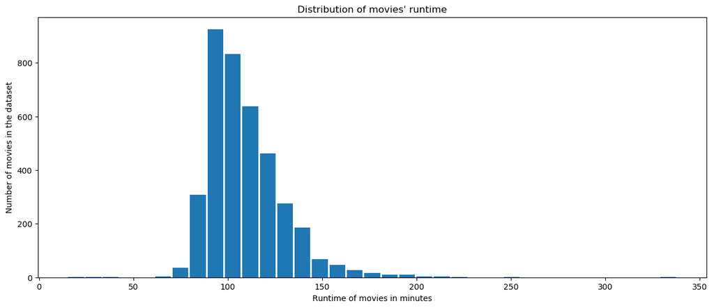

```python
draw_hist_graph(movies_cleaned,'runtime','Runtime of movies in minutes','Number of movies in the dataset',"Distribution of movies' runtime",35)
```

Most of the movies have about 80 to 120 minutes as runtime with an average of 109.22 minutes. The shortest movie runtime is 15 minutes and the longest movie runtime is 338 minutes

```python
movies_cleaned['runtime'].describe()
```

```
count    3854.000000
mean      109.220291
std        19.922820
min        15.000000
25%        95.000000
50%       106.000000
75%       119.000000
max       338.000000
Name: runtime, dtype: float64
```

About 25% of the movies have a runtime of less than or equal to 95mins.  
About 50% of the movies have a runtime of less than or equal to 106mins.  
About 75% of the movies have a runtime of less than or equal to 119mins.

##### Q5 ->

In which year was most number of movies released?

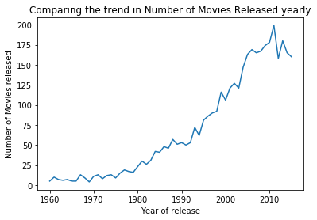

```python
#Looking at the trend line to see how the number of movies released over the years look like
movies_count_yearly = movies_cleaned.groupby('release_year')['original_title'].count()
draw_line_graph(movies_count_yearly,'Year of release','Number of Movies released','Comparing the trend in Number of Movies Released yearly')
```

The above graph suggests that there is a trend in the number of movies released over the years. The trend shows an increase in the number of movies released.

```
The highest number of movies were released in the year 2011 with 199 movies being released.
```

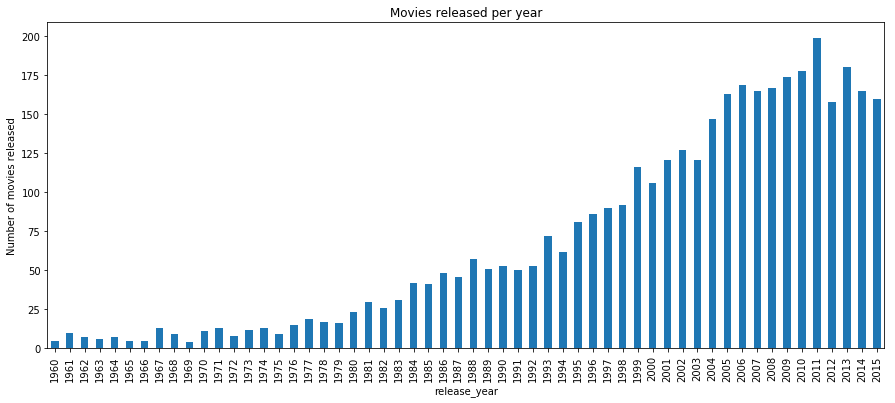

```python
#Viewing at a bar graph to see which year has the highest number of movies released
plt.figure(figsize=(15,6))
plt.xlabel("Released Year")
plt.ylabel("Number of movies released")
plt.title("Movies released per year")
movies_cleaned.groupby('release_year')['original_title'].count().plot(kind = "bar")
print("The highest number of movies were released in the year {} with {} movies being released.".format(movies_cleaned.groupby('release_year')['original_title'].count().idxmax(),movies_cleaned.groupby('release_year')['original_title'].count().max()))
```

The above graph shows that more movies are being released after 2000 than in 90s. The highest number of movies released was in 2011

##### Q6 ->

Which year yielded the most profit?

```
The year 2015 yeilded the highest total profit of $19,032,145,273.00 in the movie industry.
```

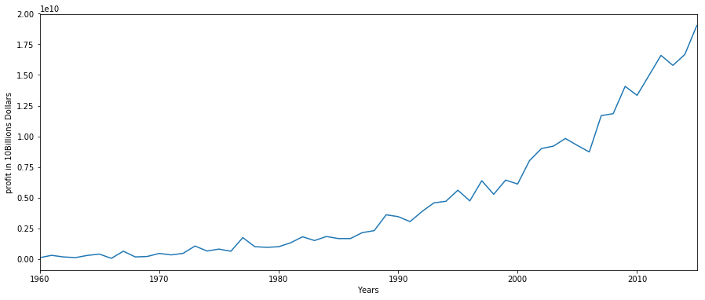

```python
#Calculating the total profit per year in the ovie industry and looking at the trend of profit
plt.figure(figsize=(15,6))
movies_cleaned.groupby('release_year')['profit_in_USD'].sum().plot(kind = 'line')
plt.ylabel("profit in 10Billions Dollars")
plt.xlabel("Years")
print("The year {} yeilded the highest total profit of {} in the movie industry.".format(movies_cleaned.groupby('release_year')['profit_in_USD'].sum().idxmax(),format_currency(movies_cleaned.groupby('release_year')['profit_in_USD'].sum().max(),  'USD', locale='en_US')))
```

```python
#selecting the movies having profit $50M or more
profit_movie = movies_cleaned[movies_cleaned['profit_in_USD'] >= 50000000]

#reindexing new data
profit_movie.index = range(len(profit_movie))

#we will start from 1 instead of 0
profit_movie.index = profit_movie.index + 1

#displaying the top few rows
profit_movie.head(3)
```

|  | budget_in_USD | revenue_in_USD | original_title | cast | director | tagline | runtime | genres | release_date | release_year | profit_in_USD |
| --- | --- | --- | --- | --- | --- | --- | --- | --- | --- | --- | --- |
| 1 | 150000000 | 1513528810 | Jurassic World | Chris Pratt\|Bryce Dallas Howard\|Irrfan Khan\|Vi... | Colin Trevorrow | The park is open. | 124.0 | Action\|Adventure\|Science Fiction\|Thriller | 2015-06-09 | 2015 | 1363528810 |
| 2 | 150000000 | 378436354 | Mad Max: Fury Road | Tom Hardy\|Charlize Theron\|Hugh Keays-Byrne\|Nic... | George Miller | What a Lovely Day. | 120.0 | Action\|Adventure\|Science Fiction\|Thriller | 2015-05-13 | 2015 | 228436354 |
| 3 | 110000000 | 295238201 | Insurgent | Shailene Woodley\|Theo James\|Kate Winslet\|Ansel... | Robert Schwentke | One Choice Can Destroy You | 119.0 | Adventure\|Science Fiction\|Thriller | 2015-03-18 | 2015 | 185238201 |

```python
def get_count_in_ascend(dataset,col,sepr = '|'):
    '''This function will count the number of times each values in the field occur and
    returns a Series in ascending oder per the count'''
    data = dataset[col].str.cat(sep = sepr)
    data = pd.Series(data.split(sepr))
    return data.value_counts(ascending = False)
```

```python
#This helps us find the genres that are popular
genre_count = get_count_in_ascend(profit_movie,'genres')
print(genre_count)
```

```
Comedy             492
Drama              481
Action             464
Thriller           405
Adventure          379
Family             229
Romance            215
Science Fiction    206
Fantasy            201
Crime              193
Horror             123
Animation          122
Mystery            113
Music               47
War                 46
History             39
Western             14
Documentary          4
Foreign              1
dtype: int64
```

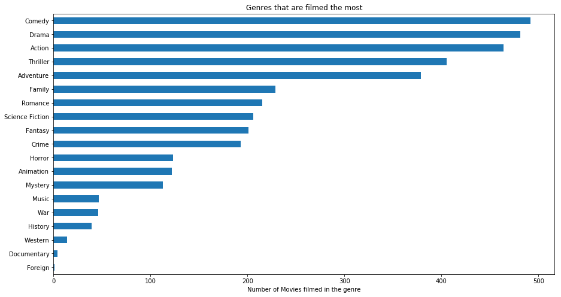

```python
#Plotting a horizontal bar chart with genres to see which genres are mostly used

genre_sort = genre_count.sort_values(ascending = True, inplace = True)
#initializing plot
ax = genre_count.plot.barh()

#giving a title
ax.set(title = 'Genres that are filmed the most')

#x-label
ax.set_xlabel('Number of Movies filmed in the genre')

#giving the figure size(width, height)
ax.figure.set_size_inches(15, 8)

#Displaying the plot
plt.show()
```

Most of the movies that made profit more than 50M USD are of the genre 'comedy'. Following the comedy genre, Drama,Action and Thriller genre also are toping the list.The genres on the bottom are War,History,Western,Documentary and Foreign.  
However this only proves that most of the movies in the $50M profit list are in Comedy,Drama,Action and Thriller, but does not prove that these genres guarantee big profits. These genres seem to attract significant interest of the audience.

```python
#creating a series with the name of directors and then number of movies they have directed.
data1 = profit_movie['director']#copying the director field into data1
data1 = pd.Series(data1)#converting data1 into a pandas series
directors_count = data1.value_counts(ascending = False)#counting the occurences of individual values in the data1 and making
#copy of it in asceding order
top_directors = directors_count[directors_count > 6] #displaying only directors who have worked in atleast 7 movies.
top_directors.head(5)
```

```
Steven Spielberg    23
Robert Zemeckis     13
Clint Eastwood      12
Tim Burton          10
Ron Howard          10
Name: director, dtype: int64
```

The list of directors is topped by Steven Spielberg with a count of 23 movies. Followed by Robert Zemeckis and Clint Eastwood

```python
#creating a top casting couch list with actors who has acted in atleast 11 movies
cast_count = get_count_in_ascend(profit_movie,'cast')
top_casting_couch = cast_count[cast_count > 10]
print(top_casting_couch)
```

```
Tom Cruise               27
Brad Pitt                25
Tom Hanks                22
Sylvester Stallone       21
Cameron Diaz             20
Adam Sandler             19
Bruce Willis             19
Jim Carrey               19
Robert De Niro           19
Denzel Washington        19
Harrison Ford            19
Ben Stiller              18
Eddie Murphy             18
Matt Damon               18
Arnold Schwarzenegger    17
Samuel L. Jackson        17
Will Smith               17
Johnny Depp              17
Nicolas Cage             16
Ralph Fiennes            16
Robin Williams           16
Gary Oldman              15
Sandra Bullock           15
Mel Gibson               15
Julia Roberts            15
Liam Neeson              15
Dwayne Johnson           14
Anne Hathaway            14
Steve Carell             14
Sean Connery             14
Angelina Jolie           14
Mark Wahlberg            14
Morgan Freeman           14
Owen Wilson              14
Michael Douglas          13
Leonardo DiCaprio        13
Tommy Lee Jones          13
George Clooney           13
John Goodman             13
Antonio Banderas         13
Keanu Reeves             12
Helena Bonham Carter     12
Patrick Stewart          12
Jack Black               12
John Travolta            12
Gene Hackman             12
Nicole Kidman            12
Anthony Hopkins          12
Meryl Streep             12
Cate Blanchett           11
Gerard Butler            11
Gwyneth Paltrow          11
Hugh Jackman             11
Forest Whitaker          11
Bill Nighy               11
Seth Rogen               11
Dustin Hoffman           11
Scarlett Johansson       11
Michael Caine            11
dtype: int64
```

The list shows the top casting couch. Tom Cruise tops the list with 27 movies followed by Brad Pitt and Tom Hanks

```python
profit_movie.head(3)
```

|  | budget_in_USD | revenue_in_USD | original_title | cast | director | tagline | runtime | genres | release_date | release_year | profit_in_USD |
| --- | --- | --- | --- | --- | --- | --- | --- | --- | --- | --- | --- |
| 1 | 150000000 | 1513528810 | Jurassic World | Chris Pratt\|Bryce Dallas Howard\|Irrfan Khan\|Vi... | Colin Trevorrow | The park is open. | 124.0 | Action\|Adventure\|Science Fiction\|Thriller | 2015-06-09 | 2015 | 1363528810 |
| 2 | 150000000 | 378436354 | Mad Max: Fury Road | Tom Hardy\|Charlize Theron\|Hugh Keays-Byrne\|Nic... | George Miller | What a Lovely Day. | 120.0 | Action\|Adventure\|Science Fiction\|Thriller | 2015-05-13 | 2015 | 228436354 |
| 3 | 110000000 | 295238201 | Insurgent | Shailene Woodley\|Theo James\|Kate Winslet\|Ansel... | Robert Schwentke | One Choice Can Destroy You | 119.0 | Adventure\|Science Fiction\|Thriller | 2015-03-18 | 2015 | 185238201 |

I would like to know movies released in which month has made the highest profits.

```python
#Making a copy of the release_date and profit columns into a new dataframe
req_list = ['release_date','profit_in_USD']
profit_release = profit_movie[req_list].copy()
profit_release.head(3)
```

|  | release_date | profit_in_USD |
| --- | --- | --- |
| 1 | 2015-06-09 | 1363528810 |
| 2 | 2015-05-13 | 228436354 |
| 3 | 2015-03-18 | 185238201 |

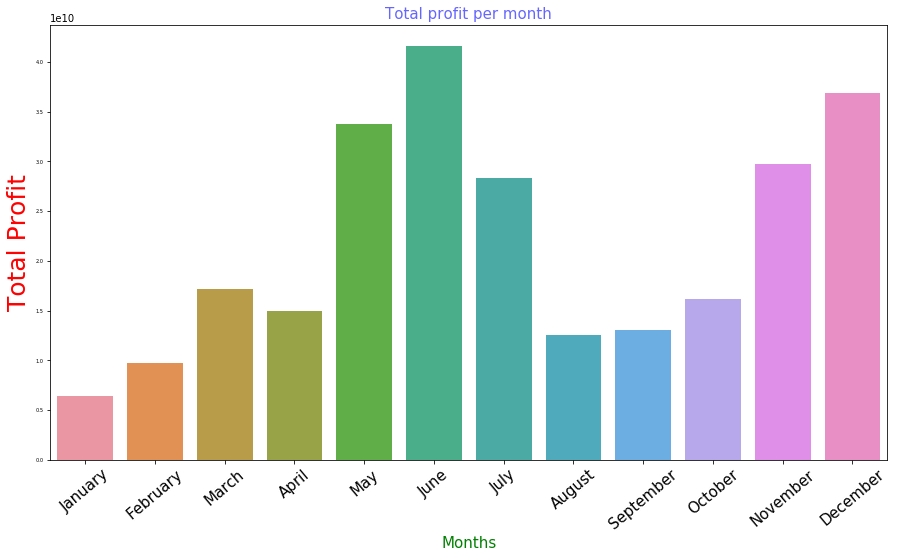

```python
#To get the months with more profits, we need to group all of the months of years and then calculate the profits of those
#months giving a new dataframe which gives 'release-date' as index
profit_release = profit_movie.set_index('release_date')

#group all the data by month, since release date is in form of index, we extract month from it
groupby_index = profit_release.groupby([(profit_release.index.month)])

#Calculating the total profit per month
profit_per_month = groupby_index['profit_in_USD'].sum()

#converting table to a dataframe
profit_per_month= pd.DataFrame(profit_per_month)

#creating a list of months
month_list = ['January', 'February', 'March', 'April', 'May', 'June', 'July', 'August', 'September', 'October', 'November', 'December']


monthly_movie_profit = sns.barplot(x = profit_per_month.index, y = profit_per_month['profit_in_USD'], data = profit_per_month)
#setting size of the graph
monthly_movie_profit.figure.set_size_inches(15,8)

#setting labels
monthly_movie_profit.set_xlabel("Months", color="g", fontsize = 15)
monthly_movie_profit.set_ylabel("Total Profit", color="r", fontsize = 25)

#setting the title and customizing
monthly_movie_profit.axes.set_title('Total profit per month', color="b", fontsize = 15, alpha = 0.6)

#customizing axes values
monthly_movie_profit.tick_params(labelsize = 5, labelcolor="black")

#rotating the x-axis values to make it readable
monthly_movie_profit.set_xticklabels(month_list, rotation = 40, size = 15)

#shows the plot
plt.show()
```

From the above plot we can find out that the month June has yielded the most profit in the movie industry followed by December and then May.

## Conclusions

From the above findings, we can come to a conclusion about what kind of a movie can be expected to make a good profit. Though this is not guaranteed, the movie can still make a good profit if it has the following features:

### Budget ->

Have a budget of greater than the mean 37,203,696.95 USD(THe profit doesn't seem to be directly linked to the budget. However to hire a top casting couch and top director we would need a good budget. This just gives an approximate amount we might need.)

### Casting couch ->

Casting can be from this list(Tom Cruise, Brad Pitt, Tom Hanks, Sylvester Stallone, Cameron Diaz, Jim Carrey, Robert De Niro, Harrison Ford , Adam Sandler, Denzel Washington, Bruce Willis, Liam Neeson, Sandra Bullock, Julia Roberts, Gary Oldman, Mel Gibson, Angelina Jolie, Owen Wilson, Dwayne Johnson, Morgan Freeman, Anne Hathaway, Steve Carell, Mark Wahlberg, Sean Connery )

### Genre ->

Choose the genre from this list(Comedy, Drama, Action , Thriller, Adventure)

### Release month ->

Release the movie in one of these months(May,June,November,December)

### Runtime ->

With a runtime between 85mins to 115 mins  
The above combination has the potential to produce a good movie which inturn can yield a good profit though not guaranteed!